# 01847291_Coursework1

## Task 1: Regression

In this task we will tackle a regression problem dealing with an engineering dataset. The dataset contains airfoils with various mechanical descriptors and we will attempt to predict the target variable 'Sound Pressure' from the other 6 mechanical descriptors.

Over this task we will create a linear regression model, then add regularisation terms to create a LASSO regression and an Elastic Nets model and finally use a kNN (k-Nearest Neighbours) regression. We will use measures such as MSE and $R^2$ to measure the performance of these regressions and try to find which model is the best fit for our data.

### 1.1 Linear Regression

We start with importing the required packages.

```python
#Import packages
import numpy as np
import pandas as pd
import matplotlib.pyplot as plt
import seaborn as sns
from collections import defaultdict
from tabulate import tabulate
```

Now we load the datasets into pandas dataframes, which is the standard representation of a matrices with row and column names in python. We can then preview the first few rows of our dataframes to better understand the datasets.

```python
#Load in training and testing data using pandas
airfoil_train = pd.read_csv('airfoil_noise_samples.csv')
airfoil_test = pd.read_csv('airfoil_noise_test.csv')
```

```python
#Preview data
airfoil_train.head(5)
```

|  | Frequency | Angle | Displacement | Chord length | Velocity | Thickness | Sound Pressure |
| --- | --- | --- | --- | --- | --- | --- | --- |
| 0 | 2175.611424 | 15.138865 | 21.075119 | 0.088194 | 66.764401 | 0.044771 | 122.365215 |
| 1 | 2962.923620 | 13.400893 | 13.200889 | 0.048462 | 78.221903 | 0.011041 | 129.296236 |
| 2 | 4430.810843 | 2.164599 | 13.959536 | 0.226743 | 57.053201 | 0.011499 | 121.827380 |
| 3 | 4939.695645 | 13.857682 | 18.203793 | 0.021705 | 23.896377 | 0.021475 | 114.998132 |
| 4 | 2193.979785 | 9.298757 | 11.007713 | 0.052737 | 38.917034 | 0.001741 | 125.639641 |

```python
#Preview data
airfoil_test.head(5)
```

|  | Frequency | Angle | Displacement | Chord length | Velocity | Thickness | Sound Pressure |
| --- | --- | --- | --- | --- | --- | --- | --- |
| 0 | 1143.654418 | 12.783087 | 15.277127 | 0.110389 | 46.089548 | 0.024076 | 125.332111 |
| 1 | 619.208992 | 4.460285 | 16.198696 | 0.284357 | 36.728360 | 0.004000 | 122.801183 |
| 2 | 646.114737 | 2.521952 | 7.533605 | 0.072292 | 59.498237 | 0.003590 | 129.361188 |
| 3 | 1246.777461 | 8.438129 | 12.396435 | 0.034411 | 47.557277 | 0.002407 | 125.656263 |
| 4 | 286.200927 | 12.238350 | 20.877161 | 0.082437 | 72.786590 | 0.036883 | 124.241736 |

We can also compute some basic statistics about our data such as simple means and standard deviations. We also check for any duplicated rows, missing observations or values of the incorrect type, which we would require data cleaning. We don't know much about the data recorded so the only assumption we can reasonably make is that all out values should be positive which we can see from the minimums.

```python
airfoil_train.describe()
```

|  | Frequency | Angle | Displacement | Chord length | Velocity | Thickness | Sound Pressure |
| --- | --- | --- | --- | --- | --- | --- | --- |
| count | 3890.000000 | 3890.000000 | 3890.000000 | 3890.000000 | 3890.000000 | 3890.000000 | 3890.000000 |
| mean | 2941.719410 | 8.231085 | 13.552404 | 0.139788 | 51.407874 | 0.014286 | 123.970283 |
| std | 2782.566725 | 5.568032 | 4.693427 | 0.092304 | 16.438326 | 0.013974 | 4.775422 |
| min | 0.337305 | 0.001490 | 0.045842 | 0.000124 | 14.877552 | 0.000002 | 102.372432 |
| 25% | 1044.921326 | 3.607908 | 10.655041 | 0.061642 | 36.962810 | 0.004142 | 120.890188 |
| 50% | 2102.066627 | 7.486780 | 13.829518 | 0.125007 | 48.562733 | 0.008539 | 124.111408 |
| 75% | 3976.531005 | 12.052639 | 16.810048 | 0.213330 | 67.863088 | 0.020909 | 127.204799 |
| max | 20884.888380 | 25.747061 | 26.970685 | 0.394016 | 87.053832 | 0.066562 | 140.469281 |

```python
airfoil_test.describe()
```

|  | Frequency | Angle | Displacement | Chord length | Velocity | Thickness | Sound Pressure |
| --- | --- | --- | --- | --- | --- | --- | --- |
| count | 973.000000 | 973.000000 | 973.000000 | 973.000000 | 973.000000 | 973.000000 | 973.000000 |
| mean | 2899.010272 | 8.168879 | 13.457254 | 0.137074 | 50.775639 | 0.014163 | 123.968845 |
| std | 2678.943633 | 5.606230 | 4.551486 | 0.093508 | 15.940928 | 0.014034 | 4.654713 |
| min | 25.769177 | 0.011299 | 0.082166 | 0.000848 | 21.139451 | 0.000002 | 107.996004 |
| 25% | 1076.460339 | 3.618578 | 10.562385 | 0.054891 | 36.987297 | 0.004148 | 121.106574 |
| 50% | 2005.178515 | 7.249896 | 13.971662 | 0.122195 | 47.345385 | 0.008715 | 124.126098 |
| 75% | 3842.996299 | 11.799025 | 16.506753 | 0.208549 | 66.755918 | 0.019872 | 127.207364 |
| max | 19744.221140 | 26.623922 | 26.393545 | 0.360646 | 84.766450 | 0.068163 | 136.422496 |

```python
#Check for no duplicated rows
#In the training set
print(np.array_equal(airfoil_train.duplicated(),[False]*len(airfoil_train)))
#In the test set
print(np.array_equal(airfoil_test.duplicated(),[False]*len(airfoil_test)))
```

```
True
True
```

```python
#Check that all values are floats
#In the training set
print(airfoil_train.dtypes)
#In the test set
print(airfoil_test.dtypes)
```

```
Frequency         float64
Angle             float64
Displacement      float64
Chord length      float64
Velocity          float64
Thickness         float64
Sound Pressure    float64
dtype: object
Frequency         float64
Angle             float64
Displacement      float64
Chord length      float64
Velocity          float64
Thickness         float64
Sound Pressure    float64
dtype: object
```

It is always a good idea to try to get a meaningful visualisation of some of our data. We may also find it helpful to construct a pairplot for the relationships between the different variables.

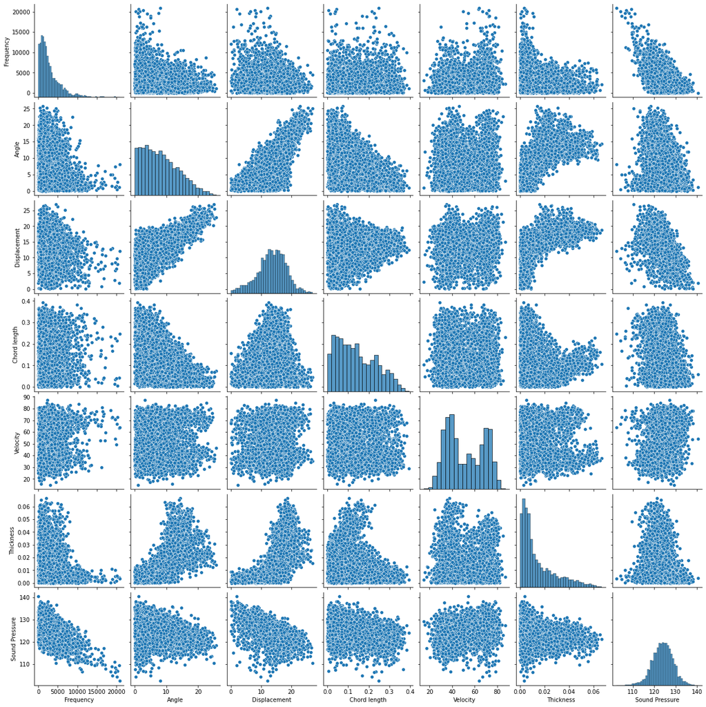

```python
#Visualise relationships
#The last row/column shows relationships with outcome variable
sns.pairplot(airfoil_train)
plt.show()
```

We will need to standardise our data. Although it won't affect the linear regression model, it will be necessary for later models, for example in the LASSO regression using unstandardised values of X will not allow our gradient descent to converge. Furthermore, it is also useful for the initial linear regression as we don't know about the scales of measurement for our predictor variables so the coefficients and intercept from our model won't have much meaning unless we standardise.

When standardising our test sets we will need to use the same paramaters as for training. So we use the standardisations:

$$ std(train_j) = \frac{train_j - mean(train_j)}{\sqrt{var(train_j)}}, std(test_j) = \frac{test_j - mean(train_j)}{\sqrt{var(train_j)}} $$

```python
#Define a standardising function
def standardise(X):
    """
    Standardises array (used for training set):

    Arguments:
      X: training set.

    Returns:
      stdX: Standardised version of input
      params: So that the same shifts can be applied to the test set
    """
    #Initialize outputs
    params = []
    stdX = np.empty(X.shape)

    #Loop through columns of input data
    for i in range(X.shape[1]):
        #Standardise each column
        mu = np.mean(X[:,i])
        std = np.std(X[:,i])
        stdX[:,i] = (X[:,i] - mu) / std
        params.append((mu,std))

    return stdX, params
```

```python
#Convert data to np arrays
train = airfoil_train.to_numpy()
test = airfoil_test.to_numpy()

#Standardize train and test sets
stdtrain, params = standardise(train)
stdtest = np.empty(test.shape)
for i in range(test.shape[1]):
    mu, sig = params[i]
    stdtest[:,i] = (test[:,i] - mu)/sig

#Separating data samples into  predictors and outcomes
stdXtrain = stdtrain[:,:-1]
stdytrain = stdtrain[:,-1]
stdXtest = stdtest[:,:-1]
stdytest = stdtest[:,-1]
```

It may also be helpful to define an unstandardising function so we can check our predicited values are reasonable.

```python
#Define an unstandardising function
def unstandardise(x, mu, sig):
    return x*sig + mu
```

For the linear regression we will be considering the loss function: $$ L(\beta) = \frac{1}{2N} \| \mathcal Y - \boldsymbol X \boldsymbol\beta - \mathbb{1} \beta_0\|^2 $$

where $\beta_0$ is a scalar and $\mathbb{1}$ the column vector of ones.

To optimise this function first we will need to find the gradient:

$$ \frac{d L}{d \beta} = - \frac{1}{N} \boldsymbol X ^ T (\mathcal Y - \boldsymbol X \boldsymbol\beta - \mathbb{ 1} \beta_0) $$$$ \frac{d L}{d \beta_0} = - \frac{1}{N} \mathbb{ 1} ^ T(\mathcal Y - \boldsymbol X \boldsymbol\beta - \mathbb{ 1} \beta_0) $$

Therefore finding the optimal solutions we get:

$$ \frac{d L}{d \beta} = 0 \Rightarrow \boldsymbol X ^ T (\mathcal Y - \boldsymbol X\boldsymbol\beta - \mathbb{ 1} \beta_0) = 0 $$$$ \boldsymbol\beta^{*} = (\boldsymbol X^T\boldsymbol X)^{-1} (\boldsymbol X ^ T \mathcal Y - \boldsymbol X ^ T \mathbb{ 1} \beta_0) $$$$ \frac{d L}{d \beta_0} = 0 \Rightarrow \mathbb{1} ^ T (\mathcal Y - \boldsymbol X \boldsymbol\beta - \mathbb{ 1} \beta_0) = 0 $$$$ \beta_0^{*} = (\mathbb{1}^T\mathbb{1})^{-1} (\mathbb{1}^T \mathcal Y - \mathbb{1}^T \boldsymbol X \beta) $$

Substituting in, we get: $$ \boldsymbol\beta^{*} = (\boldsymbol X^T (\boldsymbol I - \mathbb{1}(\mathbb{1}^T\mathbb{1})^{-1}\mathbb{1}^T) \boldsymbol X)^{-1} (\boldsymbol X ^ T (\boldsymbol I - \mathbb{1}(\mathbb{1}^T\mathbb{1})^{-1}\mathbb{1}^T) \mathcal Y) $$

When implementing this in code we will let Z be the matrix: $$ \boldsymbol Z = \boldsymbol I - \mathbb{1}(\mathbb{1}^T\mathbb{1})^{-1}\mathbb{1}^T $$

```python
#Define a function to get our optimised beta and beta_0
def max_lik_estimate(X, y):

    # X: N x D matrix of training inputs
    # y: N x 1 vector of training targets/observations
    # returns: maximum likelihood parameters (D x 1)

    N, D = X.shape
    One = np.ones(N)
    Z = np.identity(N) - np.outer((1/N) * One, One)

    beta_ml = np.linalg.inv(X.T @ Z @ X) @ X.T @ Z @ y
    beta_0 = 1/N * np.dot(One, y - X @ beta_ml)
    return beta_0, beta_ml
```

Now we can make predictions using our computed parameters and the Linear Regression model:

$$ \mathcal Y = \boldsymbol X \boldsymbol\beta + \mathbb{1} \beta_0 $$

```python
#Define a function to predict Sound Pressure from parameters
def predict_with_estimate(X, beta_0, beta_ml):

    # X_test: K x D matrix of test inputs
    # beta: D x 1 vector of parameters
    # returns: prediction of f(X_test); K x 1 vector
    N, D = X.shape
    One = np.ones(N)

    #plug parameters back into equation y = XB + B_0
    prediction = One * beta_0 + X @ beta_ml ## <-- SOLUTION

    return prediction
```

Now, applying it to our dataset we get our inferred balues for the model parameters where $\beta_0$ is the intercept term and the entries in $\beta$ are the coefficients for the respective predictor features.

```python
#Train the model on our training set
beta_0_ml, beta_ml = max_lik_estimate(stdXtrain, stdytrain)

#Previewing the inferred values of our model parameters
print(f"Beta_0 = {beta_0_ml}")
print(f"Beta = {beta_ml}")
```

```
Beta_0 = -1.801814909784971e-15
Beta = [-0.74882521  0.1747668  -0.82278635 -0.01640573  0.36126197 -0.00284062]
```

We then use our model to predict the Sound Pressures of the training set:

```python
#Predict outcome variables from the training set
ml_prediction_train = predict_with_estimate(stdXtrain, beta_0_ml, beta_ml)

#Using unstandardise we can then preview our predictions and see they are reasonable
unstandardise(ml_prediction_train, mu, sig)
```

```
array([121.31835074, 127.90696136, 121.3278463 , ..., 133.30829137,
       116.38912363, 126.5047115 ])
```

We now define our model-performance measures: $R^2$ and MSE.

$R^2$ is the coefficient of determination. It describes the proportion of the variation in the dependent variable that is predictable from our independent variables. The formula for $R^2$ is:

$$R^2 = 1 - \frac{RSS}{TSS}$$

where RSS is the residual sum of squares and TSS is the total sum of squares. It takes values in the interval [0,1].

$$$$

MSE is the mean squared error. It gives a measure of how much error loss there is in our model. The formula is:

$$MSE = \frac{1}{N} \sum_{i=1}^n (Y_i - \hat{Y}_i)^2$$

where $Y_i$ are the actual outcomes and $\hat{Y}_i$ are the predicted outcomes.

```python
#Defining R^2
def Rsquared(ypred,y):
    ybar = np.mean(y)
    RSS = np.dot(y - ypred,y - ypred)
    TSS = np.dot(y - ybar,y - ybar)
    return 1 - RSS/TSS

#Defining MSE
def MSE(ypred,y):
    N = ypred.size
    RSS = np.dot(y - ypred,y - ypred)
    return RSS/N
```

```python
#Computing the MSE and R^2 on the training set
print(f'In-sample R^2 = {Rsquared(ml_prediction_train, stdytrain)}')
print(f'In-sample MSE = {MSE(ml_prediction_train, stdytrain)}')
```

```
In-sample R^2 = 0.9177343977263076
In-sample MSE = 0.08226560227369237
```

Now we apply the same model to the test data by passing in our model parameters $\beta_0$ and $\beta$ to predict the target variable.

```python
#Predicting from the test data
ml_prediction_test = predict_with_estimate(stdXtest, beta_0_ml, beta_ml)
```

We can then compute the out-of-sample $R^2$ and MSE.

```python
#Computing the MSE and R^2 on the test set
print(f'Out-of-sample R^2 = {Rsquared(ml_prediction_test, stdytest)}')
print(f'Out-of-sample MSE = {MSE(ml_prediction_test, stdytest)}')
```

```
Out-of-sample R^2 = 0.9083172459581624
Out-of-sample MSE = 0.08703922891854736
```

Inspecting our $R^2$ and MSE, we see that we have a relatively high $R^2$ and a relatively low MSE indicating our model is a good fit for the data.

The higher the $R^2$ value the better fit the model is to the observations. Since the model was built from the training set we see that that the $R^2$ is higher in-sample (0.9177) than out-of-sample (0.9083) as it is better fit to the data in the sample.

Similarly, a lower MSE indicates a better fit to the observations than a higher MSE as it means we have smaller errors. Since the model was built from the training set we see that that the MSE is lower in-sample (0.08227) than out-of-sample (0.08704) as it is better fit to the data in the sample.

The differences seem to be reasonably small indicating the model is not excessively overfit to the training data.

### 1.2 Lasso Regression

The standardisation of the data is especially important now as we solve for our model parameters using a gradient descent. Unstandardised data would mean the gradient doesn't converge to a minimum as the step size will be affected.

Now we will employ a Lasso Regression considering the loss function:

$$ L_{LASSO}(\beta) = \frac{1}{2N} \| \mathcal Y - \boldsymbol X \boldsymbol\beta - \mathbb{1} \beta_0\|^2 + \lambda \|\beta \|_1 $$

Finding the gradient with respect to $\beta$:

$$ \frac{d L}{d \beta} = - \frac{1}{N} \boldsymbol X ^ T (\mathcal Y - \boldsymbol X \boldsymbol\beta - \mathbb{ 1} \beta_0) + \lambda \text{ sign}(\beta) $$

where sign() takes the signs of each component in $\beta$.

Finding the gradient with respect to $\beta_0$ will be the same as before:

$$ \frac{d L}{d \beta_0} = - \frac{1}{N} \mathbb{ 1} ^ T(\mathcal Y - \boldsymbol X \boldsymbol\beta - \mathbb{ 1} \beta_0) $$

```python
#We define a function for the gradient with respect to beta

#N.B. this is defined with a parameter alpha for later when we do the Elastic Nets
#For the Lasso this is just the case where alpha = 1
def get_grad_beta(X, y, beta_0, beta, lam, alpha):
    N, D = X.shape
    One = np.ones(N)

    Xy = X.T @ y
    XXb = (X.T @ X) @ beta
    Xb0 = (X.T @ One) * beta_0

    return -1/N * (Xy - XXb - Xb0) + lam * (alpha * np.sign(beta) + (1 - alpha) * 2 * beta)
```

```python
#We define a function for the gradient with respect to beta_0
def get_grad_beta_0(X, y, beta_0, beta):

    N, D = X.shape
    One = np.ones(N)

    return -1/N * One.T @ (y - X @ beta - One * beta_0)
```

Now we define a gradient descent function to optimise for our model parameters for a given value of $\lambda$. The learning rate will be redefined each iteration as it takes a value that decreases during iterations $l_r = 1/N_{iters}$.

```python
#Define a gradient descent function
def grad_desc(X, y, lam, alpha=1, n_iters=1000):
    """
    Arguments:
    X: data of size (d, n)
    y: true label vector of size (1, n)
    lam: lasso penalty hyperparameter
    alpha: default 1 for Lasso
    n_iters: number of iterations gradient descent shall update the parameters

    Returns:
    beta_0, beta: optimised model parameters
    """
    N, D = X.shape
    One = np.ones(N)

    #Initialise beta and beta_0
    beta = np.zeros(D)
    beta_0 = 1/N * np.dot(One, y - X @ beta)

    #Gradient descent
    for n_iter in range(1,n_iters+1):
        #Set learning rate
        learning_rate = 1/n_iter

        #Call gradient functions
        grad_beta = get_grad_beta(X, y, beta_0, beta, lam, alpha)
        grad_beta_0 = get_grad_beta_0(X, y, beta_0, beta)

        #Updating procedure
        beta = beta - learning_rate * grad_beta
        beta_0 = beta_0 - learning_rate * grad_beta_0

    return beta_0, beta
```

We will perform a 5-fold cross validation to tune the Lasso penalty hyper-parameter.

```python
#Define a cross validation function taht will compute the average MSE for a give lambda
def cross_validation(Xtrain, ytrain, folds, lam, alpha):
    """
    Arguments:
    Xtrain: data of size (d, n)
    ytrain: true label vector of size (1, n)
    folds: # of folds to cross validate
    lam: lasso penalty hyperparameter
    alpha: default 1 for Lasso

    Returns:
    average MSE over all folds
    """

    #Compute the indices for fold splits
    folds_indexes = np.split(np.arange(len(ytrain)), folds)

    #Initialise list of MSEs
    MSEs = []

    #Loop through folds
    for i in range(len(folds_indexes)):
        #Define validation and training sets
        val_indexes = folds_indexes[i]
        train_indexes = list(set(range(ytrain.shape[0])) - set(val_indexes))
        Xtrain_i = Xtrain[train_indexes, :]
        ytrain_i = ytrain[train_indexes]
        Xval_i = Xtrain[val_indexes, :]
        yval_i = ytrain[val_indexes]

        #Run gradient descent on training set to get model parameters
        beta_0, beta = grad_desc(Xtrain_i, ytrain_i, lam, alpha)

        #Compute MSE for model predictions against validation set
        MSE_i = MSE(predict_with_estimate(Xval_i, beta_0, beta), yval_i)
        MSEs.append(MSE_i)

    # Return average MSE
    return sum(MSEs) / len(MSEs)
```

```python
#Define a function to choose best lambda through cross validation
def choose_best(Xtrain, ytrain, folds, lam_range, alpha=1):
    """
    Arguments:
    Xtrain: data of size (d, n)
    ytrain: true label vector of size (1, n)
    folds: # of folds to cross validate
    lam_range: range of lasso penalty hyperparameters to try
    alpha: default 1 for Lasso

    Returns:
    best_lam: Optimal lambda value
    best_MSE: average MSE for cross validation with that lambda
    """

    #Initialise list of MSEs
    meanMSEs = []

    #Loop through range of lambdas
    for lam in lam_range:
        #Run a cross validation for that lambda and save the MSE result
        meanMSEs.append(cross_validation(Xtrain, ytrain, folds, lam, alpha))

    #Find the best lam and MSE
    best_lam_index = np.argmin(meanMSEs)
    best_lam = lam_range[best_lam_index]
    best_MSE = min(meanMSEs)

    #Plot scan for the hyperparameter
    plt.figure(figsize=(15, 7))
    plt.plot(lam_range,meanMSEs)
    plt.scatter(best_lam,meanMSEs[best_lam_index],color='red',marker="x",label="Minimum")
    plt.xlabel("lambda values")
    plt.ylabel("Average MSE from Cross Validation")
    plt.title("Scan of hyper-parameter lambda to find its optimal value")
    plt.legend()
    plt.show()

    return best_lam, best_MSE
```

We will run 5-fold cross validations across different ranges of lambda.

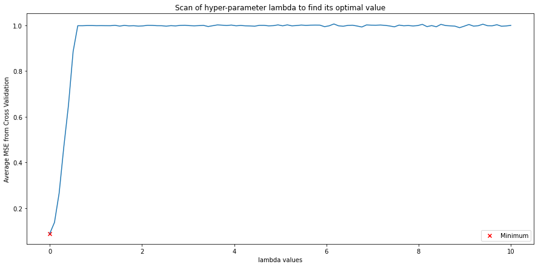

```
0.0 0.08945675517787333
```

```python
#Run a 5-fold cross validation for lambdas between 0 and 10
best_lam, best_MSE = choose_best(stdXtrain, stdytrain, 5, np.linspace(0,10,100))
print(best_lam, best_MSE)
```

We see that the MSE appears to be lowest for lambda near 0. We can now run this again with a more precise range of lambda around 0.

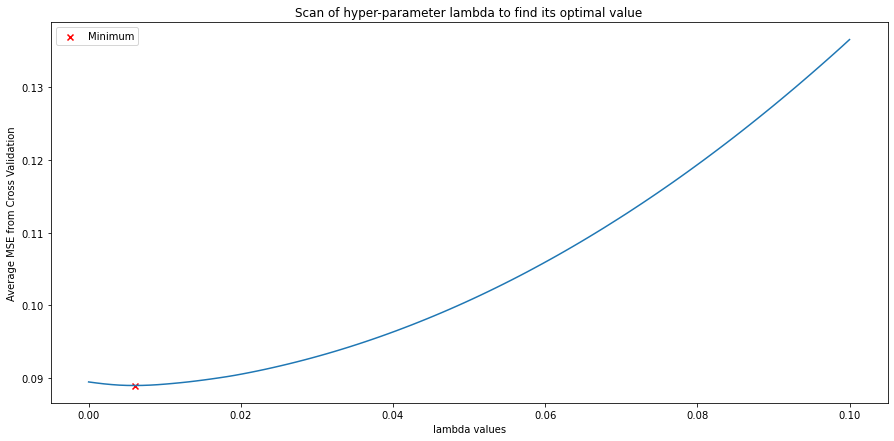

```
0.006060606060606061 0.08896602467258521
```

```python
#Run a 5-fold cross validation on a more precise range for lambda
best_lam, best_MSE = choose_best(stdXtrain, stdytrain, 5, np.linspace(0,0.1,100))
print(best_lam, best_MSE)
```

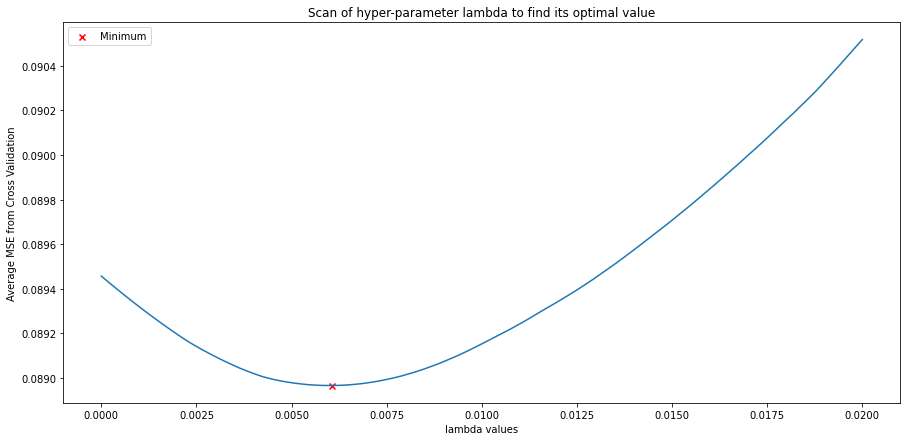

```
Optimal Lambda = 0.006060606060606061
Optimal MSE = 0.08896602467258521
```

```python
#Run a 5-fold cross validation on a more precise range for lambda again
best_lam, best_MSE = choose_best(stdXtrain, stdytrain, 5, np.linspace(0,0.02,100))
print(f'Optimal Lambda = {best_lam}')
print(f'Optimal MSE = {best_MSE}')
```

We are now at a range where we have a function shape that means we can clearly see the chosen lambda is the minimum for average MSE so we will take this value of lambda as our our optimal value.

We now choose one training/validation split and visualize our parameters as a function of the Lasso penalty.

```python
#Find 5-fold indexes
folds_indexes = np.split(np.arange(len(stdytrain)), 5)

#Pick the first split
val_indexes = folds_indexes[0]
train_indexes = list(set(range(stdytrain.shape[0])) - set(val_indexes))
Xtrain_0 = stdXtrain[train_indexes, :]
ytrain_0 = stdytrain[train_indexes]
Xval_0 = stdXtrain[val_indexes, :]
yval_0 = stdytrain[val_indexes]

#Initialise results
results = []

#Get parameter values for range of lambdas
for lam in np.linspace(0, 0.05, 100):
    beta_0, beta = grad_desc(Xtrain_0, ytrain_0, lam)
    all_betas = np.insert(beta, 0, beta_0)
    results.append(all_betas)
```

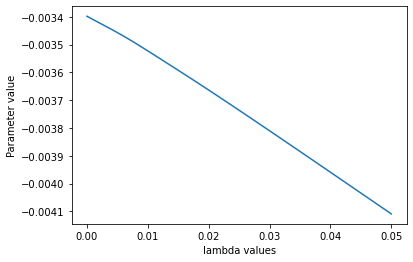

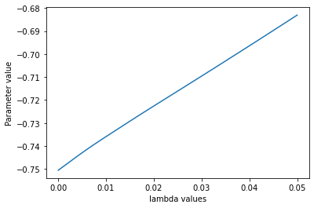

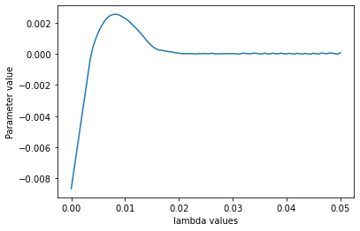

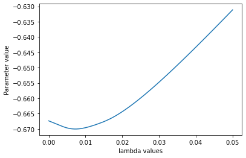

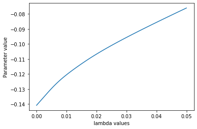

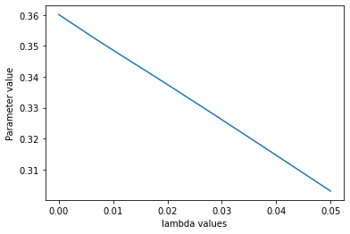

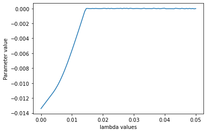

```python
#Plotting parameters as functions of lambda
results_array = np.asarray(results)
for i in range(0,7):
    param = results_array[:, i]
    plt.plot(np.linspace(0, 0.05, 100), param)
    plt.xlabel("lambda values")
    plt.ylabel("Parameter value")
    plt.show()
```

We get 7 plots, the first for $\beta_0$ and the remaining six for our components of $\beta$, the coefficients of each predictor variable.

We know that there is a tradeoff between bias and variance, i.e. unbiased model will generally have high variance and, conversely, reducing the variance will increase the bias. By the Gauss-Markov theorem, we know that the least squares estimator is the best unbiased linear estimator. However, the least squares model can have high variance so if we want to try to find a better linear model we will try find a a model that is no longer unbiased but hopefully has lower variance.

The Lasso model is an example of such a shrinkage method that introduces a 1-norm regularisation term that induces sparsity (it pushes many parameters to have small values). This will lose the unbiased nature of the least squares estimator but can give the advantage of reducing variance. We see that as we increase $\lambda$ from zero, our components of $\beta$ each move towards zero. So, as we increase lambda we get more weight on the regularisation term and the inferred parameters move towards zero. This will add more bias but can lead to lower variance and potentially a lower MSE.

We now use the model with the optimal value found in 1.2.1 to predict the outcome variable and find the in-sample and out-of-sample MSE and $R^2$ scores.

```python
#Train the model on the training set using optimal lambda
beta_0_best_lam, beta_best_lam = grad_desc(stdXtrain, stdytrain, best_lam)

#Make predictions on training set using model
lam_prediction_train = predict_with_estimate(stdXtrain, beta_0_best_lam, beta_best_lam)
```

```python
#Computing the MSE and R^2 on the train set
print(f'In-sample R^2 = {Rsquared(lam_prediction_train, stdytrain)}')
print(f'In-sample MSE = {MSE(lam_prediction_train, stdytrain)}')
```

```
In-sample R^2 = 0.9112624044238135
In-sample MSE = 0.08873759557618652
```

```python
#Make predictions on test set using model
lam_prediction_test = predict_with_estimate(stdXtest, beta_0_best_lam, beta_best_lam)

#Computing the MSE and R^2 on the test set
print(f'Out-of-sample R^2 = {Rsquared(lam_prediction_test, stdytest)}')
print(f'Out-of-sample MSE = {MSE(lam_prediction_test, stdytest)}')
```

```
Out-of-sample R^2 = 0.8976872926443761
Out-of-sample MSE = 0.09713079902397757
```

Since the model was built from the training set we see that that we get a better $R^2$ score in-sample (0.9112) than out-of-sample (0.8976) as it is better fit to the data in the sample. Similarly, we get a lower MSE in-sample (0.08874) than out-of-sample (0.09713) as it is better fit to the data in the sample.

We found that the $R^2$ and MSE are actually worse for the optimal value of $\lambda$ than for the $\lambda$ = 0 case (the standard linear regression). So although, the average MSE was higher for the $\lambda$ = 0 case during the cross-validation, once we train using the whole training set, the $\lambda$ = 0 case is the best fit for our data. Thus, introducing bias via the lasso regression did not cause enough of a reduction in variance to achieve a better model. A contributing factor may also be that with the lasso regression we needed to do a gradient descent which may not give us the exact optimal model parameters, however running very large numbers of iterations will be computationally expensive and we can see that the Lasso regression is unlikely to give a better fit even for large numbers of iterations.

### 1.3 Elastic Nets

Now we will employ an Elastic Nets Regression with cost function given by:

$$ L_{EN}(\beta) = \frac{1}{2N} \| \mathcal Y - \boldsymbol X \boldsymbol\beta - \mathbb{1} \beta_0\|^2 + \lambda [\alpha \|\beta \|_1 + (1-\alpha) \|\beta \|^2] $$

The gradient with respect to $\beta_0$ will be the same as before:

$$ \frac{d L}{d \beta_0} = - \frac{1}{N} \mathbb{ 1} ^ T(\mathcal Y - \boldsymbol X \boldsymbol\beta - \mathbb{ 1} \beta_0) $$

We already incorporated our extra terms (involving $\alpha$) into the previous functions, `get_grad_beta`, `grad_desc`, `cross_validation`, `choose_best`.

We will conduct a grid search for $\alpha = 0, 0.1, 0.5, 0.9, 1$ running cross validation to find the optimal value of lambda in each case.

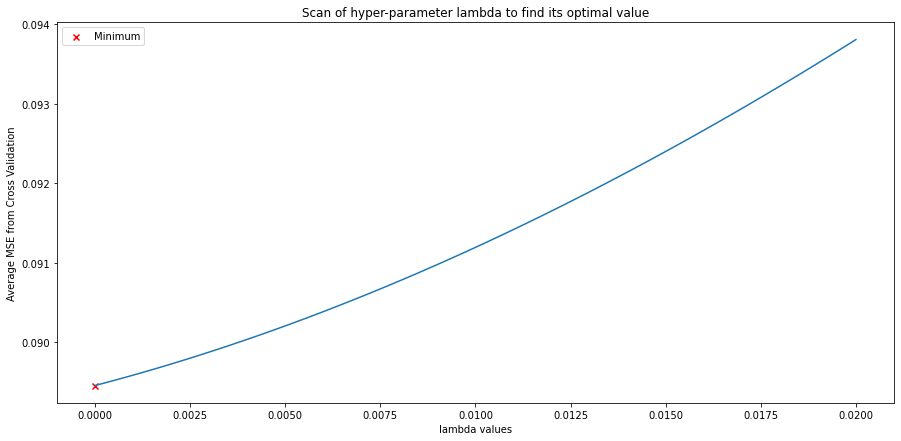

```
Alpha = 0
Best lambda = 0.0
Best MSE = 0.08945675517787333
```

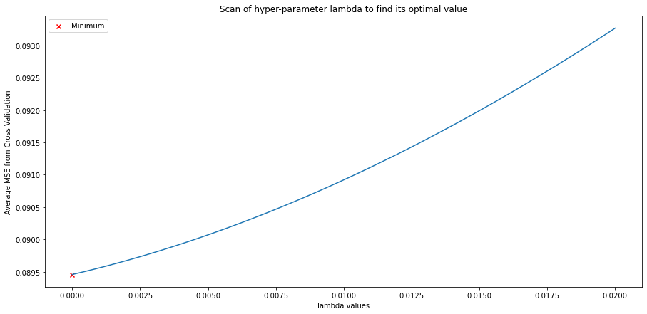

```
Alpha = 0.1
Best lambda = 0.0
Best MSE = 0.08945675517787333
```

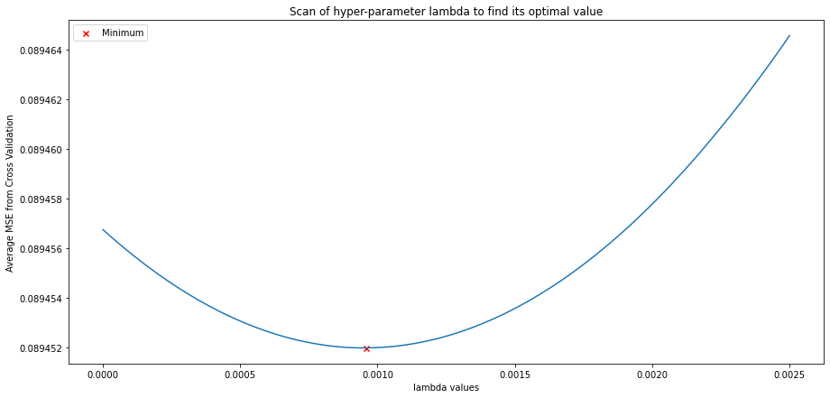

```
Alpha = 0.5
Best lambda = 0.0009595959595959596
Best MSE = 0.08945198636502731
```

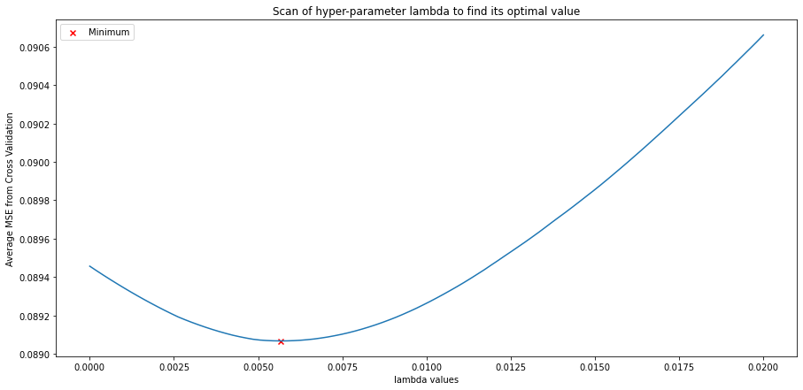

```
Alpha = 0.9
Best lambda = 0.0056565656565656566
Best MSE = 0.08906742464090843
```

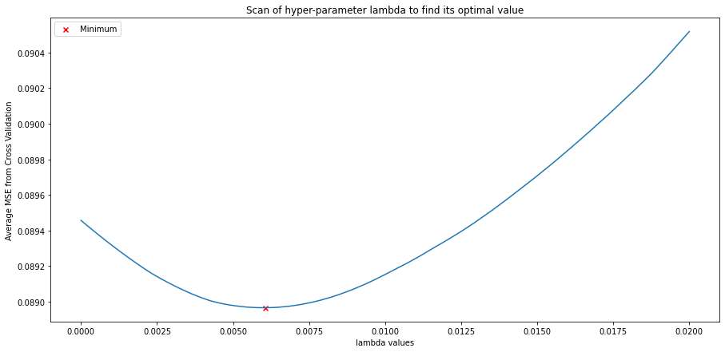

```
Alpha = 1
Best lambda = 0.006060606060606061
Best MSE = 0.08896602467258521
```

```python
#Create our list of values of alpha with lambda ranges
alpha_lambda_list = [(0, np.linspace(0, 0.02, 100)), (0.1, np.linspace(0, 0.02, 100)), (0.5, np.linspace(0, 0.0025, 100)), (0.9, np.linspace(0, 0.02, 100)), (1, np.linspace(0, 0.02, 100))]

#Initialise list of alphas and optimal lambdas
a_l_set = []

#Use choose_best to find the optimal lambda for each alpha with a 5-fold cross validation
for params in alpha_lambda_list:
    best_lam, best_MSE = choose_best(stdXtrain, stdytrain, 5, params[1], params[0])
    print(f"Alpha = {params[0]}")
    print(f"Best lambda = {best_lam}")
    print(f"Best MSE = {best_MSE}")

    #Add alpha and optimal lambda to list
    a_l_set.append((params[0], best_lam))
```

Now for each alpha, we will retrain the model on the full training set with the optimal $\lambda$ and compute the out of sample MSE and $R^2$ scores.

```python
grad_desc(stdXtrain, stdytrain, 0, 1)
```

```
(-1.844901468231603e-15,
 array([-0.74994387, -0.00530547, -0.6704575 , -0.1371828 ,  0.35893785,
        -0.01373766]))
```

```python
max_lik_estimate(stdXtrain, stdytrain)
```

```
(-1.801814909784971e-15,
 array([-0.74882521,  0.1747668 , -0.82278635, -0.01640573,  0.36126197,
        -0.00284062]))
```

```python
#Initialise list of betas
results = []

#Iterate through alphas and their respective lambdas
for i in a_l_set:
    #Print alpha and lambda
    print(f"Alpha = {i[0]}")
    print(f"Lambda = {i[1]}")

    #Train model with optimal lambda
    beta_0, beta = grad_desc(stdXtrain, stdytrain, i[1], i[0])
    #Predict outcomes for test set from model
    alpha_lam_prediction_test = predict_with_estimate(stdXtest, beta_0, beta)
    #Compute and print R^2 and MSE
    print(f"R^2 = {Rsquared(alpha_lam_prediction_test,stdytest)}")
    print(f"MSE = {MSE(alpha_lam_prediction_test,stdytest)}")
    print()

    #Append inferred parameters to list
    all_betas = np.insert(beta, 0, beta_0)
    results.append(all_betas)
```

```
Alpha = 0
Lambda = 0.0
R^2 = 0.8963808574879459
MSE = 0.09837106618039256

Alpha = 0.1
Lambda = 0.0
R^2 = 0.8963808574879459
MSE = 0.09837106618039256

Alpha = 0.5
Lambda = 0.0009595959595959596
R^2 = 0.8964397823814823
MSE = 0.09831512570007962

Alpha = 0.9
Lambda = 0.0056565656565656566
R^2 = 0.8974390543947838
MSE = 0.09736646456498807

Alpha = 1
Lambda = 0.006060606060606061
R^2 = 0.8976872926443761
MSE = 0.09713079902397757
```

Out of the values alpha = 0.1, 0.5, 0.9 we see that 0.1 has optimal lambda as 0, therefore the regularisation terms in the cost function will be zero (this will just be the regular least squares model). For alpha = 0.5 we get a slightly increased optimal lambda so there will be some regularisation, as alpha = 0.5 it will be equal between the lasso and ridge penalties. For alpha = 0.9 we get a non-zero optimal lambda so the regularisation terms in the cost function will have an impact on the model, as alpha is high in the range [0,1] most of the weight will be on the lasso penalty. We see that as we increase alpha across these values our $R^2$ gets higher and MSE gets lower. Therefore the value $\alpha$ = 0.9 provides the best model out of these cases.

Now we visualise the inferred parameters with optimal $\lambda$ for each value of $\alpha$.

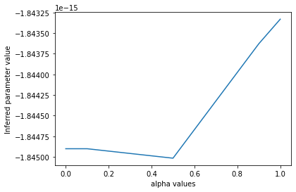

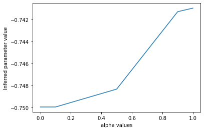

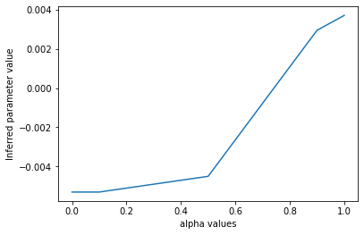

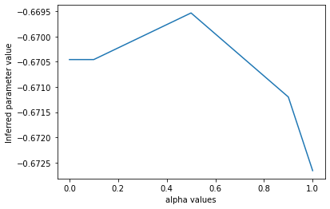

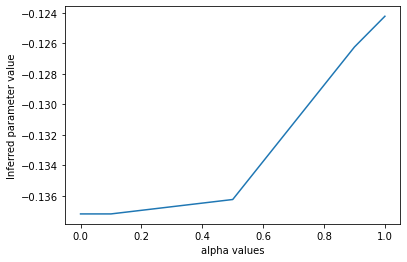

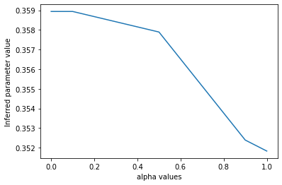

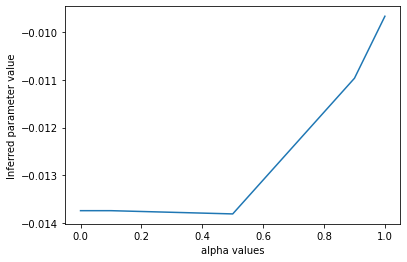

```python
results_array = np.asarray(results)
#Plot each inferred parameter in beta_0 and beta as a function of alpha
#Iterate through each parameter
for i in range(0,7):
    #Get parameter values for each alpha
    param = results_array[:, i]
    #Plot parameter values against alpha
    plt.plot([0, 0.1, 0.5, 0.9, 1], param)
    plt.xlabel("alpha values")
    plt.ylabel("Inferred parameter value")
    plt.show()
```

We get 7 plots, the first for $\beta_0$ and the remaining six for our components of $\beta$, the coefficients of each predictor variable.

As $\alpha$ = 0 has optimal lambda = 0 there will be no regularisation in the model. Generally, across our inferred parameters as we increase alpha from 0 to 0.5 to 1, we get the parameters moving towards zero as our optimal lambdas become larger so we get more weight on the regularisation term of the cost function. We see that for our the 3rd inferred paremeter in $\beta$ (our coefficient of displacement) the value shrinks for alpha = 0.5 before actually growing for alpha = 1. This is because at alpha = 1 we have just the lasso term and the lasso term doesn't necessarily push all our paremeters to zero. It promotes sparsity which means it will focus on the most important predictors.

### 1.4 kNN regression

The kNN algorithm is based on computing distances between data points. So, to start we will need to define a function that computes such a distance.

We will use the Euclidean distance $d$, defined as $$ d(\boldsymbol p, \boldsymbol q) = \sqrt{\sum_{i=1}^D{(q_i-p_i)^2}} \, , $$ where $\boldsymbol p$ and $\boldsymbol q$ are the two points in our $D$-dimensional Euclidean space.

```python
#Define the Euclidean Distance function
def euclidian_distance(p, q):
    return np.sqrt(np.sum((p-q)**2, axis=1))
```

For kNN regression it is again important to standardise our data as we have already done. This is because the calculation of distance uses our feature values so all features must be in the same scale so that certain predictors don't dominate the prediction based off of their units of measurement.

We define a function to find the *k* nearest neighbours in our training set for every test data point.

```python
#Calculate the k nearest neighbours to input data pointa
def k_neighbours(X_train, X_test, k=5, return_distance=False):
  n_neighbours = k
  dist = []
  neigh_ind = []

  # compute distance from each point x_test in X_test to all points in X_train (hint: use python's list comprehension)
  point_dist = [euclidian_distance(x_test, X_train) for x_test in X_test] ## <-- SOLUTION

  # determine which k training points are closest to each test point
  for row in point_dist:
      enum_neigh = enumerate(row)
      sorted_neigh = sorted(enum_neigh, key=lambda x: x[1])[:k]

      ind_list = [tup[0] for tup in sorted_neigh]
      dist_list = [tup[1] for tup in sorted_neigh]

      dist.append(dist_list)
      neigh_ind.append(ind_list)

  # return distances together with indices of k nearest neighbours
  if return_distance:
      return np.array(dist), np.array(neigh_ind)

  return np.array(neigh_ind)
```

Once we know which *k* neighbours are closest to our test points, we can predict the values of these test points. Our `reg_predict` function determines the outcome variable of any point $x_\text{test}$ in the test set by taking the mean of the outcomes of its neighbours.

```python
#Define a funciton to predict the outcomes of test set.
def reg_predict(X_train, y_train, X_test, k=5):
  # each of the k neighbours contributes equally to the classification of any data point in X_test
  neighbours = k_neighbours(X_train, X_test, k=k)
  # compute mean over neighbours labels (hint: use python's list comprehension)
  y_pred = np.array([np.mean(y_train[neighbour]) for neighbour in neighbours])

  return y_pred
```

We will need to use a 5-fold cross validation to find the optimal value of k.

```python
#Define a funciton to perform a cross validation for given k
def cross_validation_knn(Xtrain, ytrain, folds, k):
    #Calculate indexes for each fold
    folds_indexes = np.split(np.arange(len(ytrain)), folds)
    #Initialise list of MSEs
    MSEs = []
    #Iterate through each fold split
    for i in range(len(folds_indexes)):
        #Define training and validation sets
        val_indexes = folds_indexes[i]
        train_indexes = list(set(range(ytrain.shape[0])) - set(val_indexes))

        Xtrain_i = Xtrain[train_indexes, :]
        ytrain_i = ytrain[train_indexes]

        Xval_i = Xtrain[val_indexes, :]
        yval_i = ytrain[val_indexes]

        #Compute MSE
        MSE_i = MSE(reg_predict(Xtrain_i, ytrain_i, Xval_i, k=k), yval_i)
        MSEs.append(MSE_i)

    # Return the average MSE
    return sum(MSEs) / len(MSEs)
```

```python
#Define a function to find the optimal k for a range of values
def choose_best_knn(Xtrain, ytrain, folds, k_range):
    #Initialise list of mean MSEs
    meanMSEs = []
    #Iterate through range of ks
    for k in k_range:
        #Run cross validation and save mean MSE
        meanMSEs.append(cross_validation_knn(Xtrain, ytrain, folds, k))

    #Find optimal k and MSE
    best_k_index = np.argmin(meanMSEs)
    best_k = k_range[best_k_index]
    best_MSE = min(meanMSEs)

    #Plot scan
    plt.figure(figsize=(15, 8))
    plt.plot(k_range,meanMSEs)
    plt.scatter(best_k,meanMSEs[best_k_index],color='red',marker="x",label="Minimum")
    plt.xlabel("k")
    plt.ylabel("Mean MSE from cross validation")
    plt.title("Scan of penalty hyper-parameter to find its optimal value")
    plt.legend()
    plt.show()

    return best_k, best_MSE
```

Now we use a grid search with 5-fold cross validation to find an optimal value of the hyper-parameter *k*.

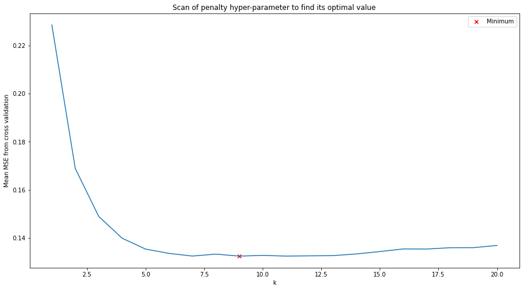

```
(9, 0.13246022658491396)
```

```python
#Search for values of k up to 20
choose_best_knn(stdXtrain, stdytrain, 5, [int(x) for x in np.linspace(1, 20, 20)])
```

We get an optimal value of *k* as 9. Now we can fix this value of *k* and retrain the model on the training set to make predictions and compute our $R^2$ and MSE on the test set.

```python
print(f'Out-of-sample R^2: {Rsquared(reg_predict(stdXtrain, stdytrain, stdXtest, k=9), stdytest)}')
print(f'Out-of-sample MSE: {MSE(reg_predict(stdXtrain, stdytrain, stdXtest, k=9), stdytest)}')
```

```
Out-of-sample R^2: 0.8621552654415879
Out-of-sample MSE: 0.1308632090280689
```

We see that we get a lower $R^2$ and higher MSE than we did for the linear regressions with and without regularisations in (1.1, 1.2, and 1.3). This means the kNN regression is a worse fit for our data implying our data is better suited to a global model than a local model. This could signify that some of our predictor variables are not as relevant or unrelated to the outcome variable as kNN prediction works best when we have few input variables and they are not redundant.

From our MSEs in 1.1, 1.2 and 1.3 we see that our best model is still the linear regression without any regularisations. This means that our added regularisation terms increased the bias but didn't reduce the variance enough to create a lower error model. The original model likely wasn't too overfit to the training data which we can see from the fact that while there was a change between the in-sample and out-of-sample MSE it was relatively small.

## Task 2: Classification

For this task we are attempting a binary classification problem dealing with a medical dataset characterising risk of diabetes. The dataset contains patient information with various measures and we will attempt to predict the classification of diabetes diagnoses based on relevant features.

Over this task we will employ a random forest model with and without appropriate weighting and then a Support Vector Machine (SVM) trying both linear and kernelised models. We will compute confusion matrices and use measures such as accuracy, precision and f-score to measure the performance of these classifications to try to find which model is the best fit for our data.

### 2.1 Random Forest

In this section we will use a random forest clasifier on the dataset employing cross-entropy as the information criterion for the splits in the decision trees. We will start with decision trees and work up to a random forest.

First loading in and previewing the data:

```python
#Load in training and testing data using pandas
diabetes_train = pd.read_csv('diabetes_samples.csv')
diabetes_test = pd.read_csv('diabetes_test.csv')
```

```python
#Preview training data
diabetes_train.head(5)
```

|  | patient_number | cholesterol | glucose | hdl_chol | chol_hdl_ratio | age | height | weight | bmi | systolic_bp | diastolic_bp | waist | hip | waist_hip_ratio | diabetes |
| --- | --- | --- | --- | --- | --- | --- | --- | --- | --- | --- | --- | --- | --- | --- | --- |
| 0 | 115 | 224 | 85 | 30 | 7,5 | 36 | 69 | 205 | 30,3 | 150 | 99 | 37 | 41 | 0,9 | No diabetes |
| 1 | 318 | 194 | 95 | 36 | 5,4 | 63 | 58 | 210 | 43,9 | 140 | 100 | 44 | 53 | 0,83 | No diabetes |
| 2 | 73 | 207 | 75 | 44 | 4,7 | 30 | 72 | 180 | 24,4 | 118 | 62 | 35 | 41 | 0,85 | No diabetes |
| 3 | 69 | 144 | 81 | 28 | 5,1 | 30 | 72 | 165 | 22,4 | 118 | 78 | 31 | 38 | 0,82 | No diabetes |
| 4 | 326 | 181 | 177 | 24 | 7,5 | 64 | 71 | 225 | 31,4 | 130 | 66 | 44 | 47 | 0,94 | Diabetes |

```python
#Preview test data
diabetes_test.head(5)
```

|  | patient_number | cholesterol | glucose | hdl_chol | chol_hdl_ratio | age | height | weight | bmi | systolic_bp | diastolic_bp | waist | hip | waist_hip_ratio | diabetes |
| --- | --- | --- | --- | --- | --- | --- | --- | --- | --- | --- | --- | --- | --- | --- | --- |
| 0 | 3 | 217 | 75 | 54 | 4 | 20 | 67 | 187 | 29,3 | 110 | 72 | 40 | 45 | 0,89 | No diabetes |
| 1 | 5 | 164 | 91 | 67 | 2,4 | 20 | 70 | 141 | 20,2 | 122 | 86 | 32 | 39 | 0,82 | No diabetes |
| 2 | 6 | 170 | 69 | 64 | 2,7 | 20 | 64 | 161 | 27,6 | 108 | 70 | 37 | 40 | 0,93 | No diabetes |
| 3 | 8 | 164 | 71 | 63 | 2,6 | 20 | 72 | 145 | 19,7 | 108 | 78 | 29 | 36 | 0,81 | No diabetes |
| 4 | 9 | 230 | 112 | 64 | 3,6 | 20 | 67 | 159 | 24,9 | 100 | 90 | 31 | 39 | 0,79 | No diabetes |

```python
#See data types for obseravtions
diabetes_train.dtypes
```

```
patient_number      int64
cholesterol         int64
glucose             int64
hdl_chol            int64
chol_hdl_ratio     object
age                 int64
height              int64
weight              int64
bmi                object
systolic_bp         int64
diastolic_bp        int64
waist               int64
hip                 int64
waist_hip_ratio    object
diabetes           object
dtype: object
```

We see that not all of the data inputs are numbers but some are objects. For the column `diabetes` clearly this is correct as the input is a string (the variable is categorical) but for the other columns the input should be numbers as we have continuous variables. Inspecting further we see that the observations have commas instead of decimal points so we will need to clean the data. We will also convert the categories in the outcome variable to booleans.

```python
#Iterate through columns that need cleaning
for x in ['chol_hdl_ratio', 'bmi', 'waist_hip_ratio']:
    #Replace , with . and convert to numeric in both datasets
    diabetes_train[x] = pd.to_numeric(diabetes_train[x].str.replace(',', '.'))
    diabetes_test[x] = pd.to_numeric(diabetes_test[x].str.replace(',', '.'))

#Convert outcome variables to 1 for diabetes, 0 for no diabetes
diabetes_train["diabetes"] = (diabetes_train["diabetes"] == "Diabetes").astype("int")
diabetes_test["diabetes"] = (diabetes_test["diabetes"] == "Diabetes").astype("int")
```

Again, we may choose to visualise the relationships between our variables. As there are more features it is more fitting to use a heatmap to view the correlations between variables.

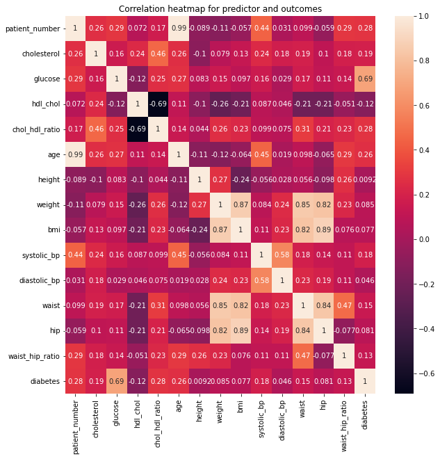

```python
#Visualise correlations
corrMatrix = diabetes_train.corr()
plt.figure(figsize = (10,10))
sns.heatmap(corrMatrix, annot=True)
plt.title("Correlation heatmap for predictor and outcomes")
plt.show()
```

Now we split the data into predictors and outcomes. Note, for the random forest we do not need to standardise our data as the decision tree splits are based off of cross-entropy which will not be affected by scaling.

```python
#Split data into predictors and outcomes
Xtrain = diabetes_train[[x for x in diabetes_train.columns if x != 'diabetes']]
ytrain = diabetes_train['diabetes']
Xtest = diabetes_test[[x for x in diabetes_test.columns if x != 'diabetes']]
ytest = diabetes_test['diabetes']
```

In order to decide our decision tree splits we will use the loss function cross-entropy which is defined as: $$ CE[\pi(R\alpha)] = − \sum_{q=1}^Q \pi_q(R_\alpha) \text{log} \pi_q(R\alpha) $$

```python
#Define a function to calculate cross-entropy
def ce(y, sample_weights):
    """
    Calculate the cross-entropy for labels.
    Arguments:
      y: vector of training labels, of shape (N,).
      sample_weights: weights for each samples, of shape (N,).
    Returns:
      (float): the cross-entropy for y.
    """
    # count different labels in y，and store in label_weights
    # initialize with zero for each distinct label.
    label_weights = {yi: 0 for yi in set(y)}
    for yi, wi in zip(y, sample_weights):
        label_weights[yi] += wi

    total_weight = sum(label_weights.values())
    ce = 0
    for label, weight in label_weights.items():
        #calculate inside of sum
        ce -= (weight / total_weight) * np.log(weight/ total_weight)

    return ce
```

Next, we define a function to split the data samples based on a feature (column) index and a numerical value. This has not much use yet, but we will call it in later functions, e.g., in the next cell in `ce_split_value`.

```python
#Define a function to split data samples
def split_samples(X, y, sample_weights, column, value):
  """
  Return the split of data whose column-th feature:
    1. equals value, in case `column` is categorical, or
    2. less than value, in case `column` is not categorical (i.e. numerical)

  Arguments:
      X: training features, of shape (N, D).
      y: vector of training labels, of shape (N,).
      sample_weights: weights for each samples, of shape (N,).
      column: the column of the feature for splitting.
      value: splitting threshold  the samples
      categorical: boolean value indicating whether column is a categorical variable or numerical.
  Returns:
      tuple(np.array, np.array): tuple of subsets of X splitted based on column-th value.
      tuple(np.array, np.array): tuple of subsets of y splitted based on column-th value.
      tuple(np.array, np.array): tuple of subsets of sample weights based on column-th value.
  """

  left_mask = (X[:, column] < value)

  X_left, X_right = X[left_mask, :], X[~left_mask, :]
  y_left, y_right = y[left_mask], y[~left_mask]
  w_left, w_right  = sample_weights[left_mask], sample_weights[~left_mask]

  return (X_left, X_right), (y_left, y_right), (w_left, w_right)
```

For a given feature index, we need to estimate the best value $s$ to use as threshold. We need to implement the function the searches for $s$ that minimizes the cross-entropy. Let's do this in the following cell by calling our previously defined two functions `split_samples` and `ce`.

```python
#Define a function to find the best value s and it's corresponding ce
def ce_split_value(X, y, sample_weights, column):
    """
    Calculate the CE based on `column` with the split that minimizes the CE.
    Arguments:
      X: training features, of shape (N, D).
      y: vector of training labels, of shape (N,).
      sample_weights: weights for each samples, of shape (N,).
      column: the column of the feature for calculating. 0 <= column < D
    Returns:
      (float, float): the resulted CE and the corresponding value used in splitting.
    """

    unique_vals = np.unique(X[:, column])

    assert len(unique_vals) > 1, f"There must be more than one distinct feature value. Given: {unique_vals}."

    ce_val, threshold = np.inf, None

    # split the values of i-th feature and calculate the cost
    for value in unique_vals:
        (X_l, X_r), (y_l, y_r), (w_l, w_r) = split_samples(X, y, sample_weights, column, value)

        # if one of the two sides is empty, skip this split.
        if len(y_l) == 0 or len(y_r) == 0:
            continue

        p_left = sum(w_l)/(sum(w_l) + sum(w_r))
        p_right = 1 - p_left
        new_cost = p_left * ce(y_l, w_l) + p_right * ce(y_r, w_r)
        if new_cost < ce_val:
            ce_val, threshold = new_cost, value

    return ce_val, threshold
```

Now we can choose the best feature to split by calling the function `ce_split_value` for each feature.

```python
#Define a function to find the best feature to split
def ce_split(X, y, sample_weights):
    """
    Choose the best feature to split according to criterion.
    Args:
      X: training features, of shape (N, D).
      y: vector of training labels, of shape (N,).
      sample_weights: weights for each samples, of shape (N,).
    Returns:
      (int, float): the best feature index and value used in splitting.
      If the feature index is None, then no valid split for the current Node.
    """

    #initialize `split_column` to None, so if None returned this means there is no valid split at the current node.
    min_ce, split_column, split_val = np.inf, None, 0
    for column in range(X.shape[1]):
        # skip column if samples are not separable by that column.
        if len(np.unique(X[:, column])) < 2:
            continue
        ce, val = ce_split_value(X, y, sample_weights, column)
        if ce < min_ce:
            min_ce, split_column, split_val = ce, column, val

    return split_column, split_val
```

Now, we define a function that returns the label which appears the most in our label variable `y`.

```python
#Define a function to choose output by the majority class from the branch
def majority_vote(y, sample_weights):
    """
    Return the label which appears the most in y.
    Args:
      y: vector of training labels, of shape (N,).
      sample_weights: weights for each samples, of shape (N,).
    Returns:
      (int): the majority label
    """
    majority_label = {yi: 0 for yi in set(y)}

    for yi, wi in zip(y, sample_weights):
        majority_label[yi] += wi
    return max(majority_label, key=majority_label.get)
```

Finally, we can build the decision tree by using `ce_split` to find the best feature to split the `X`, and `split_dataset` to get sub-trees.

```python
def build_tree(X, y, sample_weights, feature_names, depth,  max_depth=10, min_samples_leaf=2):
    """Build the decision tree according to the data.
    Args:
      X: (np.array) training features, of shape (N, D).
      y: (np.array) vector of training labels, of shape (N,).
      sample_weights: weights for each samples, of shape (N,).
      feature_names (list): record the name of features in X in the original dataset.
      depth (int): current depth for this node.

    Returns:
      (dict): a dict denoting the decision tree (binary-tree). Each node has seven attributes:
        1. 'feature_name': The column name of the split.
        2. 'feature_index': The column index of the split.
        3. 'value': The value used for the split.
        4. 'majority_label': For leaf nodes, this stores the dominant label. Otherwise, it is None.
        5. 'predicted_probability': Weighted probability of prediction
        6. 'left': The left sub-tree with the same structure.
        7. 'right' The right sub-tree with the same structure.
    """
    # include a clause for the cases where (i) no feature, (ii) all labels are the same, (iii) depth exceed, or (iv) X is too small
    if len(np.unique(y))==1 or depth>=max_depth or len(X)<=min_samples_leaf:
        return {'majority_label': majority_vote(y, sample_weights),
               'predicted_probability': sum(sample_weights[y == 1])/sum(sample_weights)}

    split_index, split_val = ce_split(X, y, sample_weights)

    # If no valid split at this node, use majority vote.
    if split_index is None:
        return {'majority_label': majority_vote(y, sample_weights)}

    (X_l, X_r), (y_l, y_r), (w_l, w_r) = split_samples(X, y, sample_weights, split_index, split_val)
    return {
        'feature_name': feature_names[split_index],
        'feature_index': split_index,
        'value': split_val,
        'majority_label': None,
        'predicted_probability':None,
        'left': build_tree(X_l, y_l, w_l, feature_names, depth + 1, max_depth, min_samples_leaf),
        'right': build_tree(X_r, y_r, w_r, feature_names, depth + 1, max_depth, min_samples_leaf)
    }
```

We define a wrapper function that we call `train` to call this `build_tree` function with the appropriate arguments.

```python
def train(X, y, sample_weights=None):
    """
    Build the decision tree according to the training data.
    Args:
      X: (pd.Dataframe) training features, of shape (N, D). Each X[i] is a training sample.
      y: (pd.Series) vector of training labels, of shape (N,). y[i] is the label for X[i], and each y[i] is
      an integer in the range 0 <= y[i] <= C. Here C = 1.
      sample_weights: weights for each samples, of shape (N,).
    """
    if sample_weights is None:
        # if the sample weights is not provided, we assume the samples have uniform weights
        sample_weights = np.ones(X.shape[0]) / X.shape[0]
    else:
        sample_weights = np.array(sample_weights) / np.sum(sample_weights)

    feature_names = X.columns.tolist()
    X = X.to_numpy()
    y = y.to_numpy()
    return build_tree(X, y, sample_weights, feature_names, depth=1)
```

Now we have all we need to build a decision tree, we want to use this fitted decision tree to make predictions. To do so, we first define a function `classify` that takes each single data point `x` as an argument. We will write a wrapper function `predict` that calls this `classify` function.

```python
def classify(tree, x):
    """
    Classify a single sample with the fitted decision tree.
    Args:
      x: ((pd.Dataframe) a single sample features, of shape (D,).
    Returns:
      (int): predicted testing sample label.
    """
    if tree['majority_label'] is not None:
        return tree['majority_label']
    else:
        if x[tree['feature_index']] < tree['value']:
            return classify(tree['left'], x)
        else:
            return classify(tree['right'], x)
```

```python
def predict(tree, X):
    """
    Predict classification results for X.
    Args:
      X: (pd.Dataframe) testing sample features, of shape (N, D).
    Returns:
      (np.array): predicted testing sample labels, of shape (N,).
    """
    X = np.asarray(X)
    if len(X.shape) == 1:
        return classify(tree, X)
    else:
        return np.array([classify(tree, x) for x in X])
```

For when we want to plot an ROC curve we will need our probabilites for each outcome prediction. As a result, we define two functions `proba` which gets the predicted probability for one prediction by taking as input one row of predictor observations, and `predict_proba` which gets the predicted probability for a vector prediction by taking as input a matrix of predictor observations.

```python
def proba(tree, x):
    """
    Get predicted probability from x.
    Args:
      x: row of sample features observations.
      tree: the decision tree that will predict from x
    Returns:
      predicted probability for x
    """
    #See if we are in the last split
    if tree['predicted_probability'] is not None:
        return tree['predicted_probability']
    #Move down a branch and recursively call function
    else:
        if x[tree['feature_index']] < tree['value']:
            return proba(tree['left'], x)
        else:
            return proba(tree['right'], x)
```

```python
def predict_proba(tree, X):
    """
    Get predicted probabilities from X.
    Args:
      X: matrix of sample features observations.
      tree: the decision tree that will predict from X
    Returns:
      predicted probabilities for X
    """
    X = np.asarray(X)
    #If X is a vector call first function
    if len(X.shape) == 1:
        return proba(tree, X)
    #Else: Call first function on each x in X
    else:
        return np.array([proba(tree, x) for x in X])
```

To evaluate how well the tree can generalise to unseen data in `X_test`, we define a short function that computes the mean accuracy.

```python
#COmpute mean accuracy
def tree_score(tree, X_test, y_test):
    y_pred = predict(tree, X_test)
    return np.mean(y_pred==y_test)
```

```python
print('Training accuracy:', tree_score(train(Xtrain, ytrain), Xtrain, ytrain))
print('Test accuracy:', tree_score(train(Xtrain, ytrain), Xtest, ytest))
```

```
Training accuracy: 1.0
Test accuracy: 0.8717948717948718
```

Now we can build the ensemble random forest model from the individual decision trees. We write the training function the constructs multiple decision trees, each operating on a subset of samples (with replacement).

```python
def train_rf(B, X, y, sample_weights=None, max_depth=2):
    """
    Build the decision tree according to the training data.
    Args:
      B: number of decision trees.
      X: (pd.Dataframe) training features, of shape (N, D). Each X[i] is a training sample.
      y: (pd.Series) vector of training labels, of shape (N,). y[i] is the label for X[i], and each y[i] is
      an integer in the range 0 <= y[i] <= C. Here C = 1.
      sample_weights: weights for each samples, of shape (N,).
    """
    if sample_weights is None:
        # if the sample weights is not provided, we assume the samples have uniform weights
        sample_weights = np.ones(X.shape[0]) / X.shape[0]
    else:
        sample_weights = np.array(sample_weights) / np.sum(sample_weights)

    feature_names = X.columns.tolist()
    X = X.to_numpy()
    y = y.to_numpy()
    N = X.shape[0]
    training_indices = np.arange(N)
    trees = []

    for _ in range(B):
        sample = np.random.choice(training_indices, N, replace=True)
        X_sample = X[sample, :]
        y_sample = y[sample]
        w_sample = sample_weights[sample]
        tree = build_tree(X_sample, y_sample, w_sample, feature_names, depth=1, max_depth=max_depth)
        trees.append(tree)

    return trees
```

Let's write the prediction function which aggregates the decision from all decision trees and returns the class with highest probability.

```python
def predict_rf(rf, X):
    """
    Predict classification results for X.
    Args:
      rf: A trained random forest through train_rf function.
      X: (pd.Dataframe) testing sample features, of shape (N, D).
    Returns:
      (np.array): predicted testing sample labels, of shape (N,).
    """
    X = np.asarray(X)
    def aggregate(decisions):
        count = defaultdict(int)
        for decision in decisions:
            count[decision] += 1
        return max(count, key=count.get)

    if len(X.shape) == 1:
        return aggregate([classify(tree, X) for tree in rf])
    else:
        return np.array([aggregate([classify(tree, x) for tree in rf]) for x in X])
```

And the function that gives the predicted probabilities for our random forest.

```python
def predict_proba_rf(rf, X):
    """
    Get predicted probabilities from X.
    Args:
      X: matrix of sample features observations.
      rf: the random forest that will predict from X
    Returns:
      predicted probabilities for X
    """
    X = np.asarray(X)
    if len(X.shape) == 1:
        return np.mean([proba(tree, X) for tree in rf])
    else:
        return np.array([np.mean([proba(tree, x) for tree in rf]) for x in X])
```

We also redefine our score function that computes the mean accuracy on our random forest.

```python
def rf_score(rf, X_test, y_test):
    y_pred = predict_rf(rf, X_test)
    return np.mean(y_pred==y_test)
```

In order to tune our hyper-parameters we will need to perform a grid search with cross-validation. The hyperparameters we will look to tune are (i) N: number of decision trees and (ii) d: depth of decision trees.

```python
#Define a function to get the indices for f folds
def get_folds(ytrain,f):
    return [int(i) for i in (np.round(np.linspace(0,len(ytrain),f+1)))]
```

```python
#Define function to run cross validation for given N and d
def cross_validation_score_rf(X_train, y_train, folds, N, d, sample_weights=None):
    #Initialise scores
    scores = []

    #Iterate through folds
    for i in range(len(folds)-1):

        #Define train and test sets
        val_indexes = np.arange(folds[i],folds[i+1])
        train_indexes = list(set(range(y_train.shape[0])) - set(val_indexes))

        X_train_i = X_train.iloc[train_indexes, :]
        y_train_i = y_train.iloc[train_indexes]

        #train random forest
        rf = train_rf(N, X_train_i, y_train_i, sample_weights=sample_weights, max_depth=d)

        #Get scores
        X_val_i = X_train.iloc[val_indexes, :]
        y_val_i = y_train.iloc[val_indexes]
        score_i = rf_score(rf,X_val_i.to_numpy(),y_val_i.to_numpy())
        scores.append(score_i)

    #Return the mean score
    return sum(scores) / len(scores)
```

```python
#Define a function to choose the best N and d from a range
def choose_best_rf(X_train, y_train, folds, N_range, d_range, sample_weights=None):

    #Initialise score matrix in both depth and tree number axis
    Nd_scores = np.zeros((len(d_range),len(N_range)))

    #Loop through n and d to get each score
    for j , n in enumerate(N_range):
        for i, d in enumerate(d_range):
            #Run cross validation score to get score
            Nd_scores[i,j] = cross_validation_score_rf(X_train, y_train, folds, n, d, sample_weights=sample_weights)

    #Get best N and d
    best_Nd_index = np.argwhere(Nd_scores==Nd_scores.max())

    #Make table of scores
    row0 = [""]+[f"Trees:{i}" for i in N_range]
    data = [row0]
    for i in range(len(Nd_scores)):
        rowi = Nd_scores[i,:]
        rowtoappend = np.concatenate(([f"Depth:{d_range[i]}"],rowi))
        data.append(rowtoappend)
    print(tabulate(data,headers='firstrow',tablefmt='fancy_grid', floatfmt=".6f"))

    return (d_range[best_Nd_index[0][0]],N_range[best_Nd_index[0][1]])
```

Now we can finally run a grid search with 4-fold cross validation to optimise our N and d. After running this with different ranges of N and d we see that after a certain level of N and d the accuracy doesn't seem to improve so we choose a suitable range of up to 5.

```python
#Get indices for 4 folds
indices = get_folds(ytrain, 4)
#Find best N,d in range 1 to 5
best_N, best_d = choose_best_rf(Xtrain, ytrain, indices, np.arange(1, 6),np.arange(1, 6))
print('Optimal # of trees:', best_N)
print('Optimal depth of trees:', best_d)
```

```
╒═════════╤═══════════╤═══════════╤═══════════╤═══════════╤═══════════╕
│         │   Trees:1 │   Trees:2 │   Trees:3 │   Trees:4 │   Trees:5 │
╞═════════╪═══════════╪═══════════╪═══════════╪═══════════╪═══════════╡
│ Depth:1 │  0.838875 │  0.838875 │  0.838875 │  0.838875 │  0.838875 │
├─────────┼───────────┼───────────┼───────────┼───────────┼───────────┤
│ Depth:2 │  0.890292 │  0.893968 │  0.897645 │  0.897645 │  0.893968 │
├─────────┼───────────┼───────────┼───────────┼───────────┼───────────┤
│ Depth:3 │  0.868340 │  0.904945 │  0.926737 │  0.897645 │  0.919491 │
├─────────┼───────────┼───────────┼───────────┼───────────┼───────────┤
│ Depth:4 │  0.875693 │  0.864557 │  0.872016 │  0.897592 │  0.890239 │
├─────────┼───────────┼───────────┼───────────┼───────────┼───────────┤
│ Depth:5 │  0.882832 │  0.912138 │  0.897592 │  0.901108 │  0.904891 │
╘═════════╧═══════════╧═══════════╧═══════════╧═══════════╧═══════════╛
Optimal # of trees: 3
Optimal depth of trees: 3
```

Now we train random forest classifier with our optimal values of N and d.

```python
#Train random forest
rf = train_rf(best_N, Xtrain, ytrain, sample_weights=None, max_depth=best_d)
```

We define a function to make a confusion matrix.

```python
def confmatrix(rf, xtest,ytest):
    #Get predictions
    y_pred = predict_rf(rf, xtest)
    ytest = np.asarray(ytest)
    #Initialise matrix
    mat = np.zeros((2,2))
    #Get values for each cell in matrix
    for truth, pred in zip(ytest,y_pred):
        if truth == 1 and pred == 1:
            mat[0,0] += 1
        if truth == 0 and pred == 1:
            mat[0,1] += 1
        if truth == 1 and pred == 0:
            mat[1,0] += 1
        if truth == 0 and pred == 0:
            mat[1,1] += 1
    return mat
```

```python
#Visualise Confusion matrix for training set
ctrain = confmatrix(rf, Xtrain, ytrain)
percentages = ctrain/sum(sum(ctrain))*100
print("Confusion matrix of training data")
print(tabulate(percentages, tablefmt='fancy_grid'))
```

```
Confusion matrix of training data
╒══════════╤═════════╕
│ 10.2564  │  1.4652 │
├──────────┼─────────┤
│  5.86081 │ 82.4176 │
╘══════════╧═════════╛
```

```python
#Visualise Confusion matrix for test set
ctest = confmatrix(rf, Xtest, ytest)
percentages = ctest/sum(sum(ctest))*100
print("Confusion matrix of test data")
print(tabulate(da, tablefmt='fancy_grid'))
```

[output not shown]

Now we define functions to get our accuracy, precision, recall and f-score from the confusion matrix.

```python
#get accuracy from confusion matrix
def accuracy(mat):
    return (mat[0,0] + mat[1,1])/ np.sum(mat)
```

```python
#get precision from confusion matrix
def precision(mat):
    return np.nan_to_num(mat[0,0] / (mat[0,0] + mat[0,1]), nan = 0)
```

```python
#get recall from confusion matrix
def recall(mat):
    return np.nan_to_num(mat[0,0] / (mat[0,0] + mat[1,0]), nan = 0)
```

```python
#get fscore from confusion matrix
def fscore(mat):
    return np.nan_to_num(2 * precision(mat) * recall(mat) / (precision(mat) + recall(mat)), nan = 0)
```

Now we can compute these scores on the training and test set.

```python
print("Accuracy of training data:", accuracy(ctrain))
print("Accuracy of test data:", accuracy(ctest))
```

```
Accuracy of training data: 0.9267399267399268
Accuracy of test data: 0.9230769230769231
```

```python
print("Precision of training data:", precision(ctrain))
print("Precision of test data:", precision(ctest))
```

```
Precision of training data: 0.875
Precision of test data: 0.8181818181818182
```

```python
print("F-score of training data:", fscore(ctrain))
print("F-score of test data:", fscore(ctest))
```

```
F-score of training data: 0.7368421052631579
F-score of test data: 0.6666666666666666
```

```python
print("Recall of training data:", recall(ctrain))
print("Recall of test data:", recall(ctest))
```

```
Recall of training data: 0.6363636363636364
Recall of test data: 0.5625
```

We see that for the random forest with our optimised hyperparameters, we get a high accuracy and precision on both the training and test data but our f-score is relatively low for both sets. This is because the recall is low. This is likely because we have an imbalanced dataset, i.e. there are far more patients without diabetes than with it. For a case like this it is likely that we care mostly about retrieval of the positive class (we want to minimize the number of positive cases that are predicted negative). As a result a low f-score is problematic.

```python
#Find numbers of patients with and without diabetes
print("# of Patients with Diabetes:", sum(ytrain))
print("# of Patients with No Diabetes:", len(ytrain) - sum(ytrain))
```

```
# of Patients with Diabetes: 44
# of Patients with No Diabetes: 229
```

A fix for this is to include appropriate weights when calculating our random forest classifier such that the sums of the the weights are the same for each case (positive cases must be weighted higher).

```python
#Initialise list of weights
weights = ytrain.copy()
for count, i in enumerate(weights):
    #Set weight for positive cases
    if weights[count] == 1:
        weights[count] = 229/44
    #Set weight for negative cases
    else:
        weights[count] = 1
```

Now we can reperform a grid search with 4-fold cross validation using our weights.

```python
#Redo cross validation with weights
best_N, best_d = choose_best_rf(Xtrain, ytrain, indices, np.arange(1, 6),np.arange(1, 6), sample_weights=np.asarray(weights))
print('Optimal # of trees:', best_N)
print('Optimal depth of trees:', best_d)
```

```
╒═════════╤═══════════╤═══════════╤═══════════╤═══════════╤═══════════╕
│         │   Trees:1 │   Trees:2 │   Trees:3 │   Trees:4 │   Trees:5 │
╞═════════╪═══════════╪═══════════╪═══════════╪═══════════╪═══════════╡
│ Depth:1 │  0.838875 │  0.838875 │  0.677110 │  0.838875 │  0.838875 │
├─────────┼───────────┼───────────┼───────────┼───────────┼───────────┤
│ Depth:2 │  0.897645 │  0.890292 │  0.893968 │  0.886616 │  0.882939 │
├─────────┼───────────┼───────────┼───────────┼───────────┼───────────┤
│ Depth:3 │  0.890399 │  0.857257 │  0.868286 │  0.879316 │  0.882939 │
├─────────┼───────────┼───────────┼───────────┼───────────┼───────────┤
│ Depth:4 │  0.879369 │  0.890345 │  0.875533 │  0.890292 │  0.886562 │
├─────────┼───────────┼───────────┼───────────┼───────────┼───────────┤
│ Depth:5 │  0.857204 │  0.850171 │  0.879316 │  0.864717 │  0.901321 │
╘═════════╧═══════════╧═══════════╧═══════════╧═══════════╧═══════════╛
Optimal # of trees: 5
Optimal depth of trees: 5
```

We retrain our optimal random forest classifier on the full training data and get our confusion matrices.

```python
#Train optimal rf
rf = train_rf(best_N, Xtrain, ytrain, sample_weights=weights, max_depth=best_d)
```

```python
#Visualise Confusion matrix for training set
ctrain = confmatrix(rf, Xtrain, ytrain)
percentages = ctrain/sum(sum(ctrain))*100
print("Confusion matrix of training data")
print(tabulate(percentages, tablefmt='fancy_grid'))
```

```
Confusion matrix of training data
╒═════════╤═════════╕
│ 14.2857 │  3.663  │
├─────────┼─────────┤
│  1.8315 │ 80.2198 │
╘═════════╧═════════╛
```

```python
#Visualise Confusion matrix for test set
ctest = confmatrix(rf, Xtest, ytest)
percentages = ctest/sum(sum(ctest))*100
print("Confusion matrix of test data")
print(tabulate(da, tablefmt='fancy_grid'))
```

[output not shown]

```python
print("Accuracy of training data:", accuracy(ctrain))
print("Accuracy of test data:", accuracy(ctest))
```

```
Accuracy of training data: 0.945054945054945
Accuracy of test data: 0.9145299145299145
```

```python
print("Precision of training data:", precision(ctrain))
print("Precision of test data:", precision(ctest))
```

```
Precision of training data: 0.7959183673469388
Precision of test data: 0.6875
```

```python
print("F-score of training data:", fscore(ctrain))
print("F-score of test data:", fscore(ctest))
```

```
F-score of training data: 0.8387096774193548
F-score of test data: 0.6875
```

By inspecting our confusion matrix we see that our values in the bottom left have now reduced (we aren't failing to predict as many positive cases). The f-score is now higher for the weighted case on both the the training and the test data. Our precision has reduced which makes as we are generally predicting positive outcomes more often so we are likely to have more false positives. Overall the accuracy for the weighted case is higher on the training set and lower on the test set so we may now have some overfitting.